# week06_in_class

1. Split on discord until 11:57 working on `isdisjoint`
2. Turn camera and mic on
3. No more than 5 per room

```python
from math import sqrt

def isdisjoint(x,y,R,xa,ya,Ra):
    # x,y,R are numbers
    # xa,ya,Ra are lists
    n=len(xa)
    for k in range(n):
        length = sqrt(pow((x - xa[k]), 2) + pow((y - ya[k]), 2)) # center to center distance
        radiusLength =  R + Ra[k] # sum of radii
        if radiusLength >= length:
            return False
    return True
```

```python
x,y,R=0,0,1 # exmaple where we shoudl get True
xa=[-2,2]
ya=[0,0]
ra=[0.5,0.5]
```

```python
isdisjoint(x,y,R,xa,ya,ra)
```

```
True
```

```python
x,y,R=0,0,1 # exmaple where we shoudl get False
xa=[-2,1]
ya=[0,0]
ra=[0.5,0.5]
```

```python
isdisjoint(x,y,R,xa,ya,ra)
```

```
False
```

for **step 3** you can check:

- if the new circle is inside the big circle and disjoint from all previously placed -> we keep it
- else pick xk,yk again

**or**

- if the new circle is not inside the big circle or not disjoint from all previously placed -> pick xk,yk again
- else we keep it

```python
if not isdisjoint(x,y,R,xa,ya,ra):
    print('They are not disjoint')
```

```
They are not disjoint
```

let's all be back here at 12:45

# Numpy

module for numerical computations

```python
import numpy as np
```

key feature -> `arrays` (list like objects)

```python
numbers=[1,2,3]
x=np.array(numbers) # changes the list into numpy array
print(numbers)
print(x)
```

```
[1, 2, 3]
[1 2 3]
```

```python
type(numbers)
```

```
list
```

```python
type(x)
```

```
numpy.ndarray
```

numpy allows **vectorial operations**

```python
print(5*x)
```

```
[ 5 10 15]
```

```python
print(5*numbers)
```

```
[1, 2, 3, 1, 2, 3, 1, 2, 3, 1, 2, 3, 1, 2, 3]
```

```python
print(x**3)
```

```
[ 1  8 27]
```

```python
y=np.array([10,20,30]) # element by element operations since dimentsions match
print(x+y)
```

```
[11 22 33]
```

```python
print(x*y)
```

```
[10 40 90]
```

```python
print(x/y)
```

```
[0.1 0.1 0.1]
```

```python
print(x)
```

```
[1 2 3]
```

```python
x+=10
print(x)
```

```
[11 12 13]
```

```python
print(x//y)
```

```
[1 0 0]
```

```python
z=np.array([1,2])
x+z
```

```
---------------------------------------------------------------------------
ValueError                                Traceback (most recent call last)
<ipython-input-16-6f5bdf0758b6> in <module>
      1 z=np.array([1,2])
----> 2 x+z

ValueError: operands could not be broadcast together with shapes (3,) (2,)
```

```python
print(x+10)
```

```
[21 22 23]
```

```python
import math as m
```

```python
x
```

```
array([11, 12, 13])
```

```python
m.log(x)
```

```
---------------------------------------------------------------------------
TypeError                                 Traceback (most recent call last)
<ipython-input-20-1507bd675c34> in <module>
----> 1 m.log(x)

TypeError: only size-1 arrays can be converted to Python scalars
```

```python
np.log(x)
```

```
array([2.39789527, 2.48490665, 2.56494936])
```

```python
dir(np)
```

[output not shown]

[output cut: 567 more lines]

[output not shown]

```python
np.cos(x)
```

```
array([0.0044257 , 0.84385396, 0.90744678])
```

`numpy` has its own version of common functions (in vectorial form)

```python
np.pi
```

```
3.141592653589793
```

`arrays` can be used in `for` loops, and can be sliced, the same way as `lists`

```python
x
```

```
array([11, 12, 13])
```

```python
for k in x:
    print(k)
```

```
11
12
13
```

```python
x[1]
```

```
12
```

```python
w=np.array(range(11))
print(w)
```

```
[ 0  1  2  3  4  5  6  7  8  9 10]
```

```python
print(w[::2])
```

```
[ 0  2  4  6  8 10]
```

**Note:** slicing an array won't produce a copy of the array, but it will produce a view of the array

```python
a=w[:4]
a[2]=78
print(w)
```

```
[ 0  1 78  3  4  5  6  7  8  9 10]
```

to make a copy of an array we need to use `copy()`

```python
w=np.array(range(11))
a=w.copy()
a[2]=55
print(w,a)
```

```
[ 0  1  2  3  4  5  6  7  8  9 10] [ 0  1 55  3  4  5  6  7  8  9 10]
```

```python
w=np.array(range(11))
a=w[:4].copy()
a[2]=55
print(w,a)
```

```
[ 0  1  2  3  4  5  6  7  8  9 10] [ 0  1 55  3]
```

## Summary

numpy array

- array must contain only one type of object
- their size cannot be changed after creation (unlike lists where we can `append`, `insert`, `pop`)
- can be indexed as lists
- slicing won't make a copy (need to use `copy()`)
- support vectorial operations (unlike lists)
- are mutable

## How to create arrays

1. from a list using `np.array()`

```python
a=np.array([1,2,3,4,5])
b=np.array(range(2,40,5))
print(a,b)
```

```
[1 2 3 4 5] [ 2  7 12 17 22 27 32 37]
```

1. As an array of zeros or ones

```python
c=np.zeros(6)
d=np.ones(11)
print(c,d)
```

```
[0. 0. 0. 0. 0. 0.] [1. 1. 1. 1. 1. 1. 1. 1. 1. 1. 1.]
```

**Ex.** How do we get an array with 10 elements that are all 7's

```python
e=7*np.ones(10)
print(e)
```

```
[7. 7. 7. 7. 7. 7. 7. 7. 7. 7.]
```

1. As an array of values that are not initialized `np.empty()`. (This is faster than `np.ones` and `np.zeros` for large dimensions)

```python
f=np.empty(12)
print(f)
```

```
[1.28176610e-311 3.16202013e-322 0.00000000e+000 0.00000000e+000
 0.00000000e+000 2.38545895e+180 1.42605355e-071 1.88627693e+185
 8.69520684e-071 7.99933759e+169 2.09028752e-076 5.75529782e-066]
```

```python
f[2]=22
f[3:]=9
print(f)
```

```
[1.2817661e-311 3.1620201e-322 2.2000000e+001 9.0000000e+000
 9.0000000e+000 9.0000000e+000 9.0000000e+000 9.0000000e+000
 9.0000000e+000 9.0000000e+000 9.0000000e+000 9.0000000e+000]
```

1. Using `np.arange`

```python
g=np.arange(6)
print(g)
```

```
[0 1 2 3 4 5]
```

```python
h=np.arange(0.1,0.8,0.05) # we can use non-integers
print(h)
```

```
[0.1  0.15 0.2  0.25 0.3  0.35 0.4  0.45 0.5  0.55 0.6  0.65 0.7  0.75]
```

1. Using `np.linspace(a,b,n)`. (evenly spaced points in [a,b] with n points, i.e. (n-1) steps )

```python
i=np.linspace(0,1,6)
print(i)
```

```
[0.  0.2 0.4 0.6 0.8 1. ]
```

**Note** using `numpy` is faster than lists

```python
from time import time
import math as m
```

```python
print(time()) # how many second have passed from Jan 1st 1970
```

```
1602087438.7950335
```

```python
print(time())
```

```
1602087495.8743072
```

```python
startt=time()
print('I am fine today')
endt=time()
print(endt-startt)
```

```
I am fine today
0.0
```

```python
startt=time()
y=[m.cos(k) for k in range(10**8)]
endt=time()
print(endt-startt)
```

```
41.00789999961853
```

```python
startt=time()
y=np.cos(np.arange(10**8))
endt=time()
print(endt-startt)
```

```
5.783024311065674
```

## Matplotlib and numpy

```python
import matplotlib.pyplot as plt
```

**Ex** plot $\cos(x)$ for x in $[0,2\pi]$ using at least 101 points (with `numpy`)

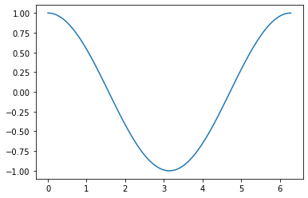

```python
x=np.linspace(0,2*np.pi,101)
y=np.cos(x)
plt.plot(x,y)
plt.show()
```

```python
stepsize=2*np.pi/100
z=np.arange(0,2*np.pi+stepsize,stepsize)
len(z)
```

```
101
```

```python
np.arange(0,77,2)
```

```
array([ 0,  2,  4,  6,  8, 10, 12, 14, 16, 18, 20, 22, 24, 26, 28, 30, 32,
       34, 36, 38, 40, 42, 44, 46, 48, 50, 52, 54, 56, 58, 60, 62, 64, 66,
       68, 70, 72, 74, 76])
```

**Ex** the derivative of $f$ is defined as: $$f'(x)=\lim_{h\to 0} \frac{f(x+h)-f(x)}{h}$$

so, if $h\simeq 0$ (small enough), we can say that $f'(x)\simeq \frac{f(x+h)-f(x)}{h} \quad (*)$

Approximate the derivative of $f(x)=\sin(x)$ on $[0,2\pi]$ using the formula above, and then plot it on the same graph as the real derivative

- compute `fpapp` the approximated derivative using (*) (for 10 steps, 100 steps)
- compute the real derivative `fp`
- plot all 3 curves

Post the plot on the discord channel **deriv.approx.** with your name in the title

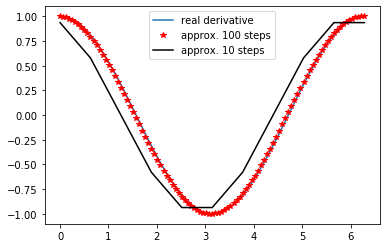

```python
x=np.linspace(0,2*np.pi,101) # fine approx - 101 points - 100 steps
h1=x[1]-x[0] # step for fine approximation
w=np.linspace(0,2*np.pi,11) # coarse approx
h2=w[1]-w[0] # step for coarse approximation

fp=np.cos(x) # real derivative
fpapp1=(np.sin(x+h1)-np.sin(x))/h1
fpapp2=(np.sin(w+h2)-np.sin(w))/h2

plt.plot(x,fp,label='real derivative')
plt.plot(x,fpapp1,'*r',label='approx. 100 steps')
plt.plot(w,fpapp2,'k',label='approx. 10 steps')
plt.legend()
plt.show()
```

## subplots

`plt.subplot(n,k,h)` Allow for a figure containing $n\times k $ plots

- `n` number of rows
- `k` number of cols
- `h` position (starting at 1)

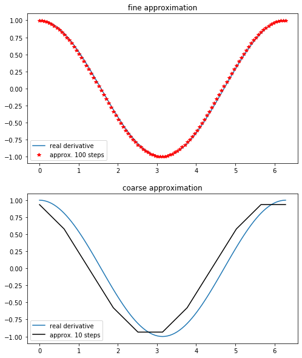

```python
plt.figure(figsize=(8,10))

plt.subplot(2,1,1)
plt.plot(x,fp,label='real derivative')
plt.plot(x,fpapp1,'*r',label='approx. 100 steps')
plt.legend()
plt.title('fine approximation')
plt.subplot(2,1,2)
plt.plot(x,fp,label='real derivative')
plt.plot(w,fpapp2,'k',label='approx. 10 steps')
plt.legend()
plt.title('coarse approximation')
plt.show()
```

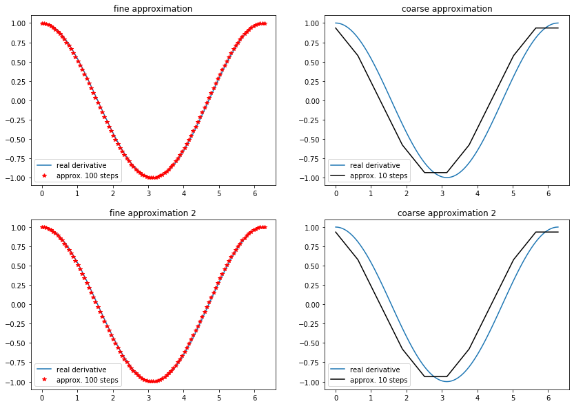

```python
plt.figure(figsize=(14,10))

plt.subplot(2,2,1)
plt.plot(x,fp,label='real derivative')
plt.plot(x,fpapp1,'*r',label='approx. 100 steps')
plt.legend()
plt.title('fine approximation')
plt.subplot(2,2,2)
plt.plot(x,fp,label='real derivative')
plt.plot(w,fpapp2,'k',label='approx. 10 steps')
plt.legend()
plt.title('coarse approximation')
plt.subplot(2,2,3)
plt.plot(x,fp,label='real derivative')
plt.plot(x,fpapp1,'*r',label='approx. 100 steps')
plt.legend()
plt.title('fine approximation 2')
plt.subplot(2,2,4)
plt.plot(x,fp,label='real derivative')
plt.plot(w,fpapp2,'k',label='approx. 10 steps')
plt.legend()
plt.title('coarse approximation 2')
plt.show()
```